# Are the effects of air pollution disproportionnate across countries depending on GDP ?

## By Giang Le and Julia Kobic

```r
library(tidyverse)
library(readxl)
library(reshape2)
```

# Introduction

Since the Industrial Revolution air pollution, which is defined by the World Health Organisation as *“contamination of the indoor or outdoor environment by any chemical, physical or biological agent that modifies the natural characteristics of the atmosphere.”* has been rising exponentially. Although the effects are devastating worldwide (The World Health Organisation estimates that over 99% of the world population is exposed to a level of air pollution above their guideline limits), levels of exposure and their consequences seem to vary according to countries and regions. Indeed, the WHO also states that 89% of premature deaths linked to air pollution occurred in low- and middle-income countries, which would suggest that these countries feel the impact of environmental transgressions much more intensely than higher income countries.

Which countries are more exposed to air pollution and its consequences ? More precisely, is there a link between air pollution and pollution-related deaths and GDP ?

# Data

Since there has yet to be a dataset on the internet that provides all the measurements we needed, we had to gather and merge data from various sources. For air pollution levels, we use data from ourworldindata.org this data includes the mean annual average exposure of air to pollution for each country in the world.

In addition, we use 2 other data sets from The World Bank’s DataBank (https://databank.worldbank.org) from this data we could get the yearly average life expectancy at birth, as well as the GDP per capita of most countries.

Finally, we are using a dataset from the OECD (https://data.oecd.org) in order to obtain the statistics on early mortality linked to air pollution.

Because these data sets did not perfectly match each other, both format-wise and content-wise, we had to remove several variables and entries in order to merge them into one final set.

```r
# Read data from csv files
life_expectancy <- read.csv("./life_expectancy.csv")
air_pollution <- read.csv("./air_pollution.csv")
gdp_per_capita <- read.csv("./gdp_per_capita.csv")
pollution_deaths <- read_csv("./pollution_deaths.csv")
# Modify data, removing unnecessary variables, and uniforming variable names
air_pollution <- air_pollution %>%
  rename(pollution_level = PM2.5.air.pollution..mean.annual.exposure..micrograms.per.cubic.meter.,
         country_name = Entity,
         country_code = Code,
         year = Year) %>%
  mutate(year = as.numeric(year), pollution_level = as.numeric(pollution_level))

life_expectancy <- life_expectancy %>%
  select(-Series.Name, -Series.Code) %>%
  rename(country_name = Country.Name,
         country_code = Country.Code) %>%
  melt(id.vars = c("country_name", "country_code"), variable.name = "year") %>%
  rename(life_expectancy = value) %>%
  mutate(year = as.numeric(str_sub(year, 2, 5)), life_expectancy = as.numeric(life_expectancy))

gdp_per_capita <- gdp_per_capita %>%
  select(-Indicator.Name, -Indicator.Code) %>%
  rename(country_name = Country.Name,
         country_code = Country.Code) %>%
  melt(id.vars = c("country_name", "country_code"), variable.name = "year") %>%
  rename(gdp_per_capita = value) %>%
  mutate(year = as.numeric(str_sub(year, 2, 5)))

pollution_deaths <- subset(pollution_deaths, select = -c(SUBJECT, MEASURE, FREQUENCY, INDICATOR))

pollution_deaths <- pollution_deaths %>%
  rename(country_code = LOCATION,
         year = TIME,
         deaths_per_1000000 = Value) %>%
  mutate(year = as.numeric(year), deaths_per_1000000 = as.numeric(deaths_per_1000000))
```

```r
# Merge to one data frame
country_data <- merge(air_pollution, life_expectancy)
country_data <- merge(country_data, gdp_per_capita)
country_data <- merge(country_data, pollution_deaths)


# Clean the data, removing NA entries
country_data_clean = country_data %>%
  select(-`Flag Codes`) %>%
  mutate(life_expectancy = ifelse(life_expectancy != "..", life_expectancy, NA)) %>%
  filter(!is.na(life_expectancy), !is.na(gdp_per_capita), !is.na(pollution_level))

# Look inside the merged data
head(country_data_clean)
```

```
##   country_code year country_name pollution_level life_expectancy gdp_per_capita
## 1          AFG 2005  Afghanistan        64.52268          58.361       255.0551
## 2          AFG 2010  Afghanistan        65.24559          60.851       554.5952
## 3          AFG 2011  Afghanistan        66.83572          61.419       621.9123
## 4          AFG 2012  Afghanistan        66.02317          61.923       663.1411
## 5          AFG 2013  Afghanistan        61.36674          62.417       651.9879
## 6          AFG 2014  Afghanistan        59.01033          62.545       628.1468
##   deaths_per_1000000
## 1            145.510
## 2            168.657
## 3            179.324
## 4            194.944
## 5            211.610
## 6            221.849
```

```r
country_data_clean %>%
  summarise("Mean pollution level" = mean(pollution_level),
            "Median pollution level" = median(pollution_level),
            "Mean life expectancy" = mean(life_expectancy),
            "Median life expectancy" = median(life_expectancy),
            "Min pollution level" = min(pollution_level),
            "Max pollution level" = max(pollution_level),
            "Mean pollution-related deaths" = mean(deaths_per_1000000),
            "Median pollution-related deaths" = median(deaths_per_1000000))
```

```
##   Mean pollution level Median pollution level Mean life expectancy
## 1             29.15822               24.25265             69.52677
##   Median life expectancy Min pollution level Max pollution level
## 1               71.84878            5.861331            100.7844
##   Mean pollution-related deaths Median pollution-related deaths
## 1                       370.686                         292.926
```

# Descriptive Statistics

The final data set includes statistics from 1990, 1995, 2000, 2005, and from 2010 to 2017 in 166 countries. The pollution level ranges from 5.8 to 100.8 micrograms of PM2.5 per cubic meter, with the distribution greatly right-skewed, meaning very few countries, at a point in time, have a super-fifty air pollution level. Looking at the other variables, GDP per capita has a quite similar distribution to pollution level and the pollution-related deaths, while the distribution of life expectancy is left-skewed - almost the exact opposite. Considering that these stats were taken at the same place and time, there could be a correlation between these variables.

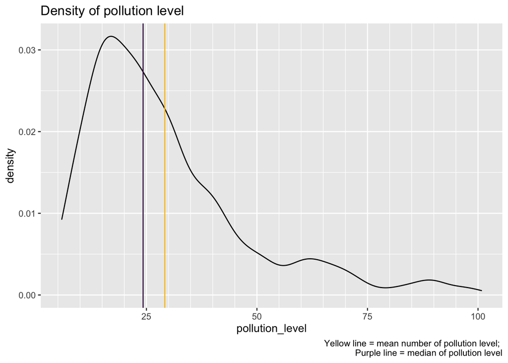

```r
# Density graphs
country_data_clean %>%
  ggplot() +
  aes(x = pollution_level) +
  geom_density() +
  geom_vline(xintercept = mean(country_data_clean$pollution_level), color="#ffc000") +
  geom_vline(xintercept = median(country_data_clean$pollution_level), color="#440154FF") +
  labs(title = "Density of pollution level",
       caption = "Yellow line = mean number of pollution level;
                  Purple line = median of pollution level") +
  scale_x_continuous(minor_breaks = seq(0, 100, 5))
```

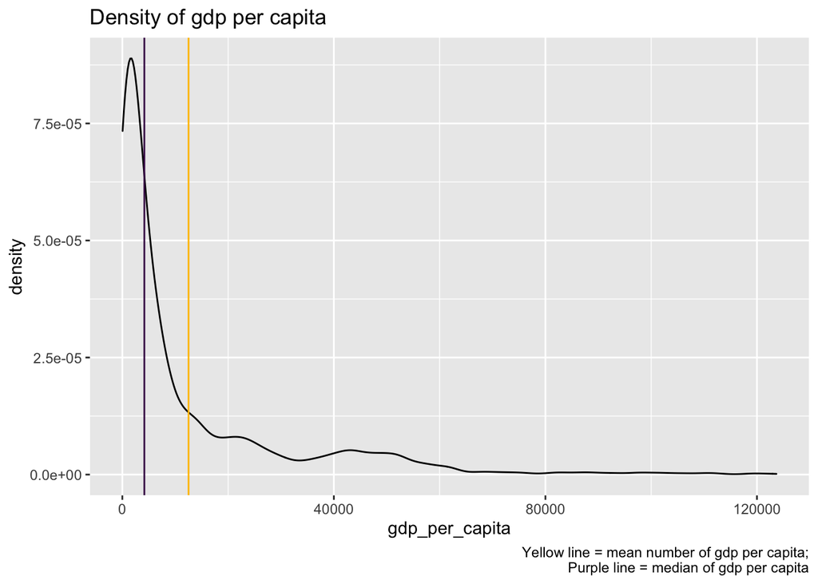

```r
country_data_clean %>%
  ggplot() +
  aes(x = gdp_per_capita) +
  geom_density() +
  geom_vline(xintercept = mean(country_data_clean$gdp_per_capita), color="#ffc000") +
  geom_vline(xintercept = median(country_data_clean$gdp_per_capita), color="#440154FF") +
  labs(title = "Density of gdp per capita",
       caption = "Yellow line = mean number of gdp per capita;
                  Purple line = median of gdp per capita")
```

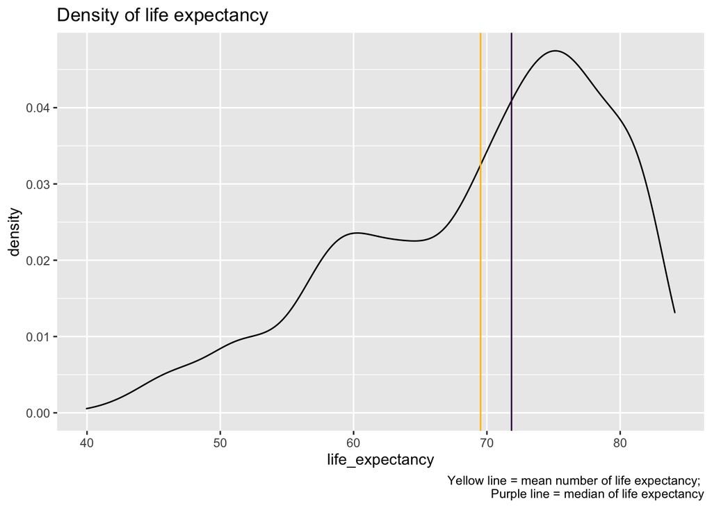

```r
country_data_clean %>%
  ggplot() +
  aes(x = life_expectancy) +
  geom_density() +
  geom_vline(xintercept = mean(country_data_clean$life_expectancy), color="#ffc000") +
  geom_vline(xintercept = median(country_data_clean$life_expectancy), color="#440154FF") +
  labs(title = "Density of life expectancy",
       caption = "Yellow line = mean number of life expectancy;
                  Purple line = median of life expectancy") +
  scale_x_continuous(minor_breaks = seq(30, 100, 10))
```

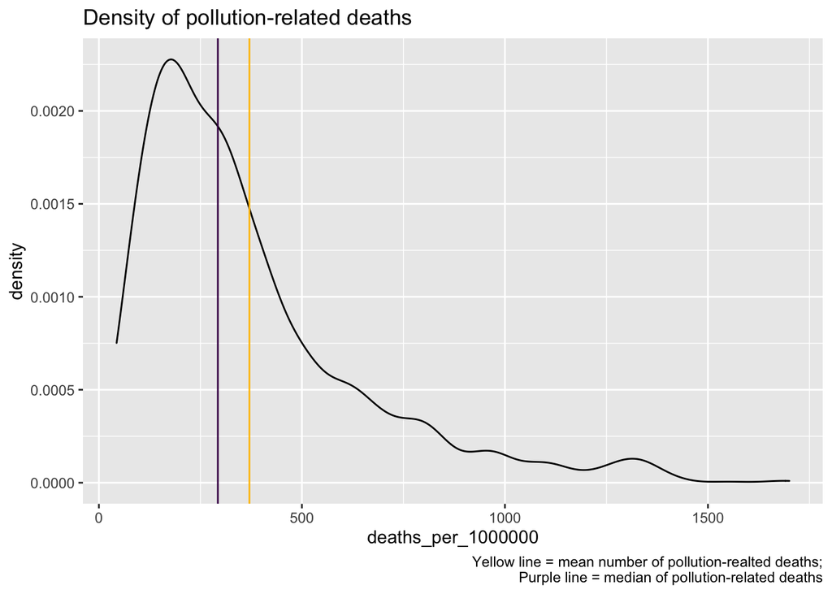

```r
country_data_clean %>%
  ggplot() +
  aes(x = deaths_per_1000000) +
  geom_density() +
  geom_vline(xintercept = mean(country_data_clean$deaths_per_1000000), color="#ffc000") +
  geom_vline(xintercept = median(country_data_clean$deaths_per_1000000), color="#440154FF") +
  labs(title = "Density of pollution-related deaths",
       caption = "Yellow line = mean number of pollution-realted deaths;
                  Purple line = median of pollution-related deaths")
```

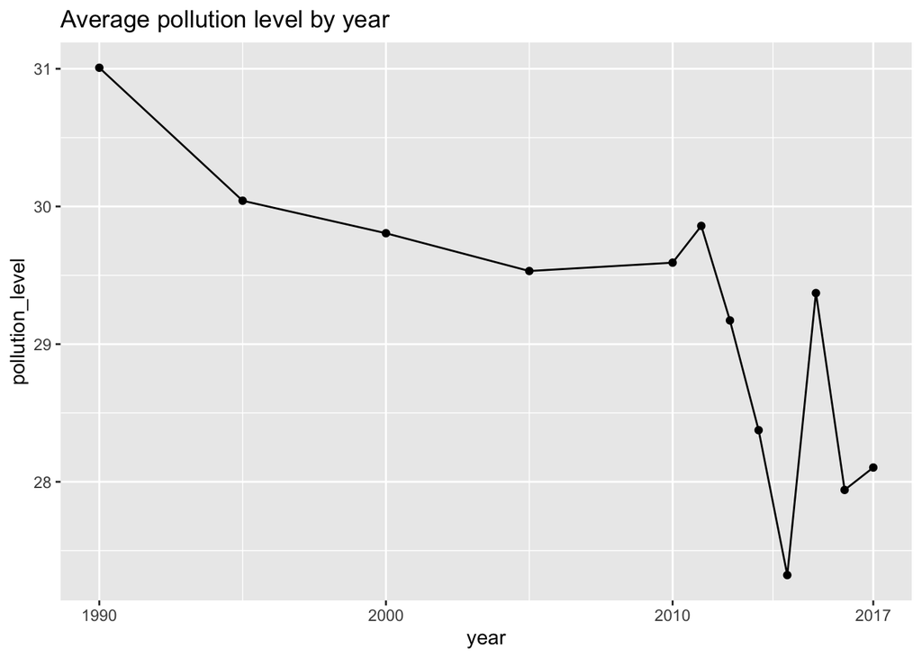

```r
# World average by year graphs
avg_by_year <- country_data_clean %>%
  group_by(year) %>%
  summarise(year = year, pollution_level = mean(pollution_level), life_expectancy = mean(life_expectancy), gdp_per_capita = mean(gdp_per_capita), deaths_per_1000000 = mean(deaths_per_1000000), .groups = 'drop') %>%
  distinct(.keep_all = TRUE)

avg_by_year %>%
  ggplot() +
  aes(x = year, y = pollution_level) +
  geom_line() +
  geom_point() +
  labs(title = "Average pollution level by year") +
  scale_x_continuous(breaks= c(1990, 2000, 2010, 2017))
```

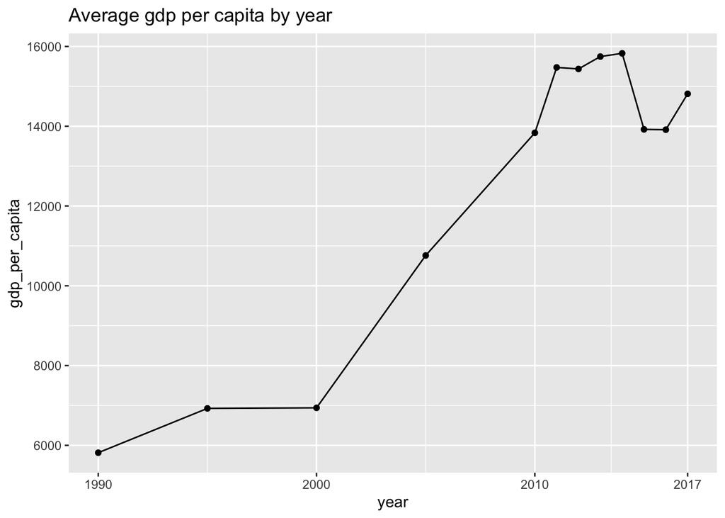

```r
avg_by_year %>%
  ggplot() +
  aes(x = year, y = gdp_per_capita) +
  geom_line() +
  geom_point() +
  labs(title = "Average gdp per capita by year") +
  scale_x_continuous(breaks= c(1990, 2000, 2010, 2017))
```

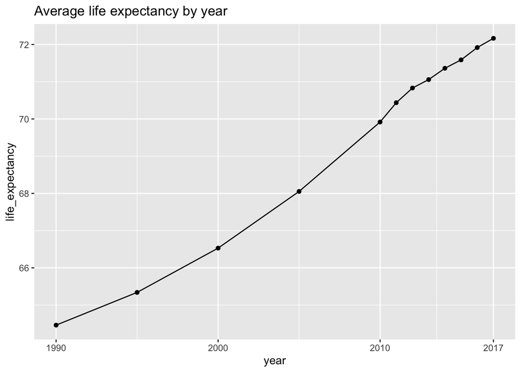

```r
avg_by_year %>%
  ggplot() +
  aes(x = year, y = life_expectancy) +
  geom_line() +
  geom_point() +
  labs(title = "Average life expectancy by year") +
  scale_x_continuous(breaks= c(1990, 2000, 2010, 2017))
```

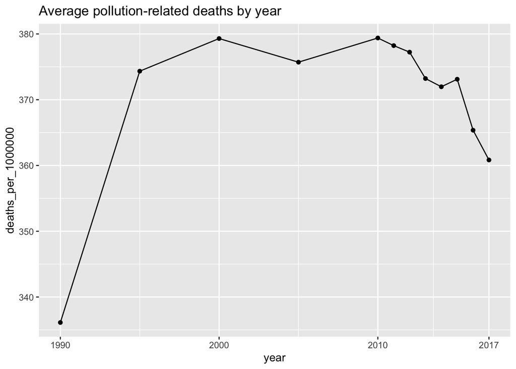

```r
avg_by_year %>%
  ggplot() +
  aes(x = year, y = deaths_per_1000000) +
  geom_line() +
  geom_point() +
  labs(title = "Average pollution-related deaths by year") +
  scale_x_continuous(breaks= c(1990, 2000, 2010, 2017))
```

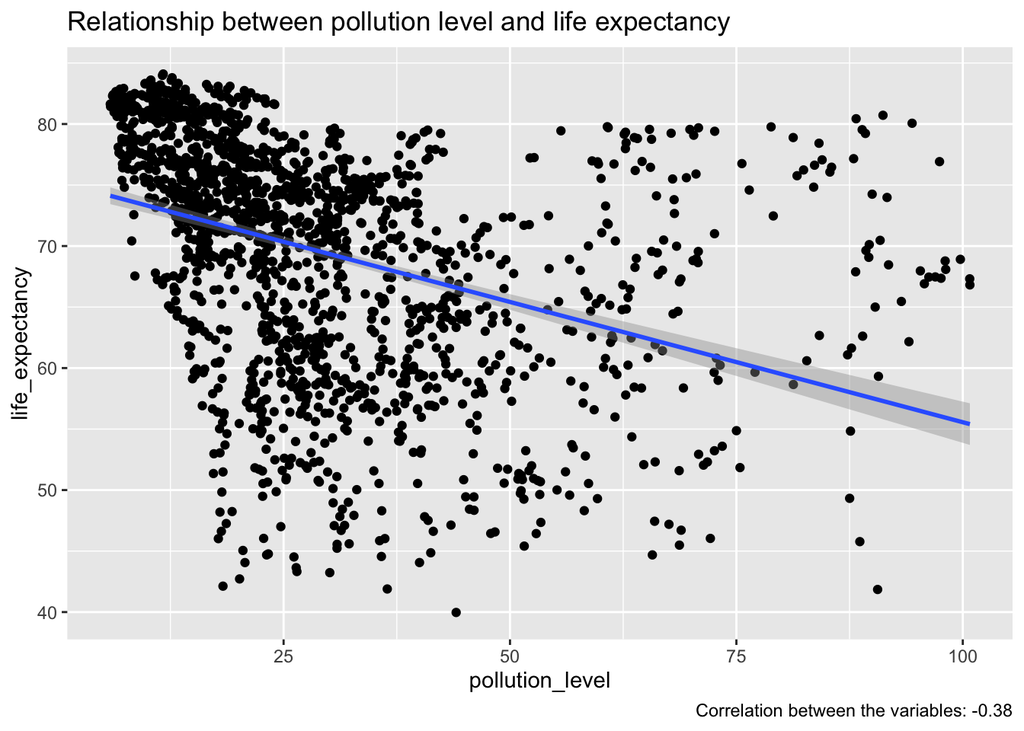

```r
# Life expectancy / pollution level plot
correl_le_pl = as.character(round(cor(country_data_clean$life_expectancy, country_data_clean$pollution_level), 2))

country_data_clean %>%
  ggplot() +
  aes(x = pollution_level, y = life_expectancy) +
  geom_point() +
  geom_smooth(method = "lm") +
  labs(title = "Relationship between pollution level and life expectancy") +
  labs(caption = paste0("Correlation between the variables: ", correl_le_pl))
```

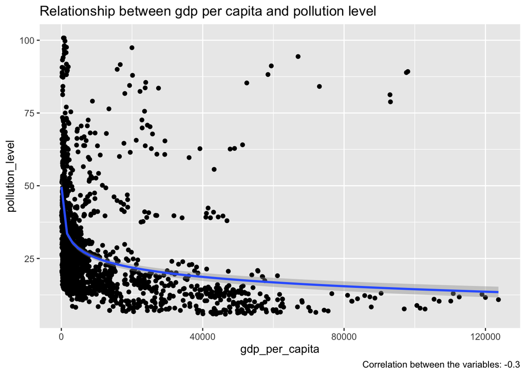

```r
# Pollution level / GDP per capita plot
correl_pl_gdp = as.character(round(cor(country_data_clean$pollution_level, country_data_clean$gdp_per_capita), 2))
country_data_clean %>%
  ggplot() +
  aes(x = gdp_per_capita, y = pollution_level) +
  geom_point() +
  geom_smooth(method = "lm", formula = y ~ log(x)) +
  labs(title = "Relationship between gdp per capita and pollution level") +
  labs(caption = paste0("Correlation between the variables: ", correl_pl_gdp))
```

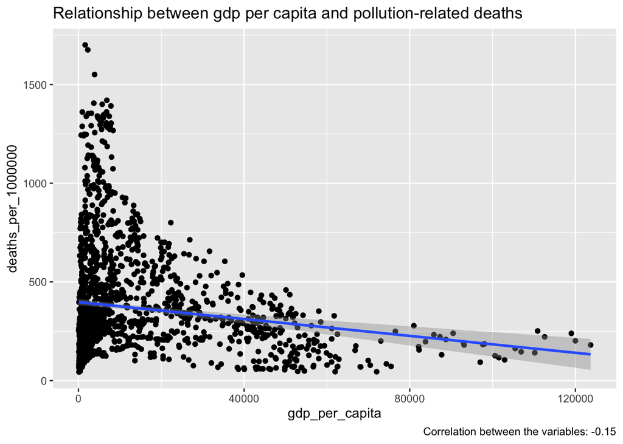

```r
# Pollution-related deaths / GDP per capita plot

correl_prd_gdp = as.character(round(cor(country_data_clean$deaths_per_1000000, country_data_clean$gdp_per_capita), 2))
country_data_clean %>%
  ggplot() +
  aes(x = gdp_per_capita, y = deaths_per_1000000) +
  geom_point() +
  geom_smooth(method = "lm") +
  labs(title = "Relationship between gdp per capita and pollution-related deaths") +
  labs(caption = paste0("Correlation between the variables: ", correl_prd_gdp))
```

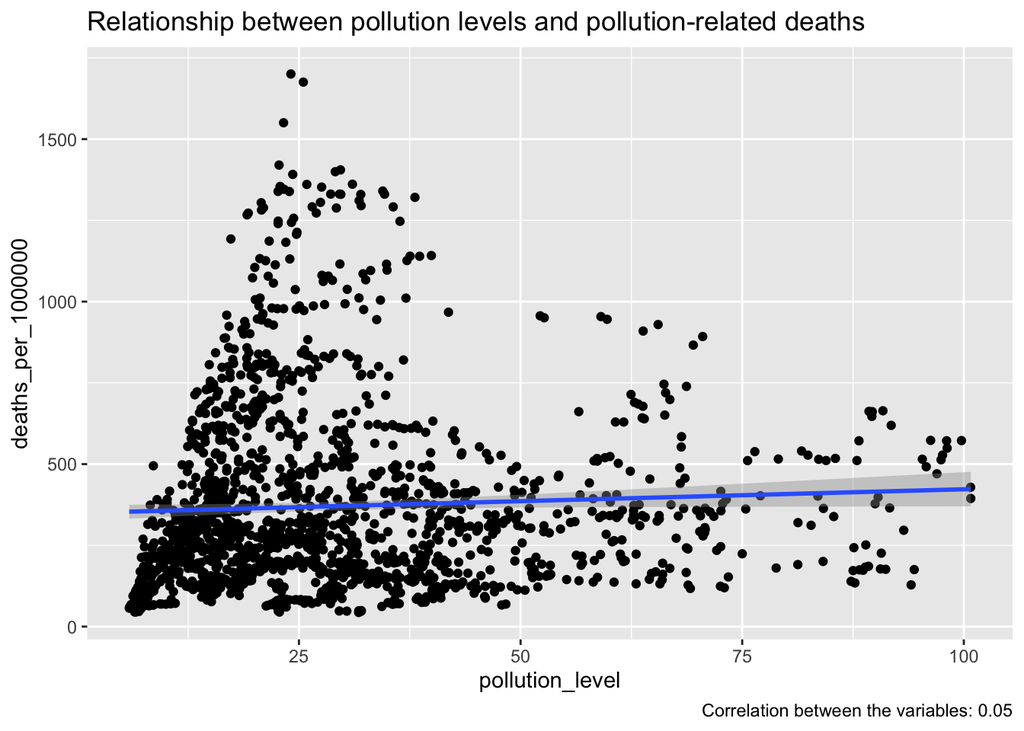

```r
# Pollution-related deaths / GDP per capita plot

correl_prd_pl = as.character(round(cor(country_data_clean$deaths_per_1000000, country_data_clean$pollution_level), 2))
country_data_clean %>%
  ggplot() +
  aes(x = pollution_level, y = deaths_per_1000000) +
  geom_point() +
  geom_smooth(method = "lm") +
  labs(title = "Relationship between pollution levels and pollution-related deaths") +
  labs(caption = paste0("Correlation between the variables: ", correl_prd_pl))
```

# Methodology

Now that we have established the existence of a correlation between GDP and pollution levels as well as GDP and pollution-related deaths, it is time to investigate a possible causal effect between GDP and our two other variables of interest. In order to do so, we will be using regression analysis. We will being by determining the most adapted model for each correlation by running both a linear and a logarithmic regression, and comparing the r^2 coefficients. The model with the highest coefficient is best suited to the analysis.

```r
# Pollution level / GDP per capita regression
pollution_gdp <- lm(country_data_clean$pollution_level ~ country_data_clean$gdp_per_capita)
summary(pollution_gdp)
```

```
##
## Call:
## lm(formula = country_data_clean$pollution_level ~ country_data_clean$gdp_per_capita)
##
## Residuals:
##     Min      1Q  Median      3Q     Max
## -23.403 -10.939  -5.246   4.690  85.103
##
## Coefficients:
##                                     Estimate Std. Error t value Pr(>|t|)
## (Intercept)                        3.282e+01  5.116e-01   64.16   <2e-16 ***
## country_data_clean$gdp_per_capita -2.925e-04  2.263e-05  -12.93   <2e-16 ***
## ---
## Signif. codes:  0 '***' 0.001 '**' 0.01 '*' 0.05 '.' 0.1 ' ' 1
##
## Residual standard error: 17.54 on 1693 degrees of freedom
## Multiple R-squared:  0.08982,    Adjusted R-squared:  0.08928
## F-statistic: 167.1 on 1 and 1693 DF,  p-value: < 2.2e-16
```

```r
# Pollution level / GDP per capita regression (log)
pollution_gdp <- lm(country_data_clean$pollution_level ~ log(country_data_clean$gdp_per_capita))
summary(pollution_gdp)
```

```
##
## Call:
## lm(formula = country_data_clean$pollution_level ~ log(country_data_clean$gdp_per_capita))
##
## Residuals:
##     Min      1Q  Median      3Q     Max
## -25.468 -10.289  -4.593   3.509  78.113
##
## Coefficients:
##                                        Estimate Std. Error t value Pr(>|t|)
## (Intercept)                             67.7659     2.1550   31.45   <2e-16 ***
## log(country_data_clean$gdp_per_capita)  -4.6323     0.2539  -18.25   <2e-16 ***
## ---
## Signif. codes:  0 '***' 0.001 '**' 0.01 '*' 0.05 '.' 0.1 ' ' 1
##
## Residual standard error: 16.8 on 1693 degrees of freedom
## Multiple R-squared:  0.1643, Adjusted R-squared:  0.1638
## F-statistic: 332.9 on 1 and 1693 DF,  p-value: < 2.2e-16
```

It appears that the best suited model to express the relationship between pollution levels and GDP per capita is the logarithmic model as 0.1638 > 0.08928. Therefore, the regression of GDP per capita on pollution levels will have the following formula : pollution levels = β0 + β1 × log(GDP per capita) + ε

So, lower-income countries do indeed seem to be more exposed to air pollution.

The relationship between pollution levels and log(GDP per capita) can be represented in the following graph :

[figure not shown]

```r
# Pollution level / GDP per capita plot
correl_pl_gdp = as.character(round(cor(country_data_clean$pollution_level, country_data_clean$gdp_per_capita), 2))
country_data_clean %>%
  ggplot() +
  aes(x = log(gdp_per_capita), y = pollution_level) +
  geom_point() +
  geom_smooth(method = "lm") +
  labs(title = "Relationship between gdp per capita and pollution level") +
  labs(caption = paste0("Correlation between the variables: ", correl_pl_gdp))
```

Now, let’s apply the same reasoning to the relationship between pollution-related deaths and GDP :

```r
# Pollution-related deaths / GDP per capita regression
deaths_gdp <- lm(country_data_clean$deaths_per_1000000 ~ country_data_clean$gdp_per_capita)
summary(deaths_gdp)
```

```
##
## Call:
## lm(formula = country_data_clean$deaths_per_1000000 ~ country_data_clean$gdp_per_capita)
##
## Residuals:
##     Min      1Q  Median      3Q     Max
## -353.65 -200.45  -68.63  101.65 1306.40
##
## Coefficients:
##                                     Estimate Std. Error t value Pr(>|t|)
## (Intercept)                        3.975e+02  8.008e+00  49.636  < 2e-16 ***
## country_data_clean$gdp_per_capita -2.138e-03  3.542e-04  -6.037 1.93e-09 ***
## ---
## Signif. codes:  0 '***' 0.001 '**' 0.01 '*' 0.05 '.' 0.1 ' ' 1
##
## Residual standard error: 274.5 on 1693 degrees of freedom
## Multiple R-squared:  0.02107,    Adjusted R-squared:  0.02049
## F-statistic: 36.44 on 1 and 1693 DF,  p-value: 1.927e-09
```

```r
# Pollution-related deaths / GDP per capita regression (log)
deaths_gdp_log <- lm(country_data_clean$deaths_per_1000000 ~ log(country_data_clean$gdp_per_capita))
summary(deaths_gdp_log)
```

```
##
## Call:
## lm(formula = country_data_clean$deaths_per_1000000 ~ log(country_data_clean$gdp_per_capita))
##
## Residuals:
##     Min      1Q  Median      3Q     Max
## -388.56 -185.73  -83.74   97.06 1350.49
##
## Coefficients:
##                                        Estimate Std. Error t value Pr(>|t|)
## (Intercept)                             187.113     35.288   5.302 1.29e-07 ***
## log(country_data_clean$gdp_per_capita)   22.026      4.157   5.298 1.32e-07 ***
## ---
## Signif. codes:  0 '***' 0.001 '**' 0.01 '*' 0.05 '.' 0.1 ' ' 1
##
## Residual standard error: 275.1 on 1693 degrees of freedom
## Multiple R-squared:  0.01631,    Adjusted R-squared:  0.01573
## F-statistic: 28.07 on 1 and 1693 DF,  p-value: 1.324e-07
```

Therefore, it appears necessary to run a multiple regression in order to take into account other factors in order to hypothesise a more accurate causal relationship.

# Results and analysis

```r
# Deaths / everything regression
death <- lm(country_data_clean$deaths_per_1000000 ~ country_data_clean$gdp_per_capita + country_data_clean$pollution_level + country_data_clean$life_expectancy)
summary(death)
```

```
##
## Call:
## lm(formula = country_data_clean$deaths_per_1000000 ~ country_data_clean$gdp_per_capita +
##     country_data_clean$pollution_level + country_data_clean$life_expectancy)
##
## Residuals:
##     Min      1Q  Median      3Q     Max
## -421.51 -170.77  -51.52   97.53 1231.41
##
## Coefficients:
##                                      Estimate Std. Error t value Pr(>|t|)
## (Intercept)                        -7.411e+02  5.811e+01 -12.753  < 2e-16 ***
## country_data_clean$gdp_per_capita  -6.691e-03  4.042e-04 -16.554  < 2e-16 ***
## country_data_clean$pollution_level  1.910e+00  3.539e-01   5.397 7.75e-08 ***
## country_data_clean$life_expectancy  1.639e+01  8.164e-01  20.082  < 2e-16 ***
## ---
## Signif. codes:  0 '***' 0.001 '**' 0.01 '*' 0.05 '.' 0.1 ' ' 1
##
## Residual standard error: 246.8 on 1691 degrees of freedom
## Multiple R-squared:  0.2096, Adjusted R-squared:  0.2082
## F-statistic: 149.5 on 3 and 1691 DF,  p-value: < 2.2e-16
```

```r
# Pollution level / GDP per capita regression
expectancy_gdp <- lm(country_data_clean$life_expectancy ~ country_data_clean$gdp_per_capita)
summary(expectancy_gdp)
```

```
##
## Call:
## lm(formula = country_data_clean$life_expectancy ~ country_data_clean$gdp_per_capita)
##
## Residuals:
##     Min      1Q  Median      3Q     Max
## -25.724  -4.785   2.160   5.763  12.012
##
## Coefficients:
##                                    Estimate Std. Error t value Pr(>|t|)
## (Intercept)                       6.562e+01  2.218e-01  295.88   <2e-16 ***
## country_data_clean$gdp_per_capita 3.118e-04  9.810e-06   31.78   <2e-16 ***
## ---
## Signif. codes:  0 '***' 0.001 '**' 0.01 '*' 0.05 '.' 0.1 ' ' 1
##
## Residual standard error: 7.602 on 1693 degrees of freedom
## Multiple R-squared:  0.3736, Adjusted R-squared:  0.3732
## F-statistic:  1010 on 1 and 1693 DF,  p-value: < 2.2e-16
```